# Andreas Handel Introduction

# Introducing myself

This is the introduction page for Andreas Handel.

## A picture

Here is a picture of me pursuing one of my favorite activities.

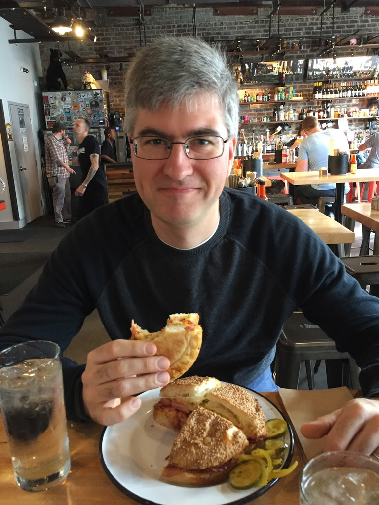

This is a Muffaletta Sandwich from [Cochon Butcher](https://cochonbutcher.com/) in New Orleans.

## More about me

Now I am going to cheat a little bit and mostly link to existing material that introduces me. Those sources above will tell you about my education, training, research and some hobbies.

You can read a bit more about my work and my training on my [group website](http://handelgroup.uga.edu/) and also [on my person website](https://www.andreashandel.com/).

UGA’s office of online learning also made a general introductory video for me.

[video not shown]

## A cool data analysis link

There are a lot of cool data analysis projects out there by now. Here is one from 538, which gives a nice [interactive illustration of the phenomenon of *p-hacking*](https://projects.fivethirtyeight.com/p-hacking/), which basically means investigators playing with data until they get something *statistically significant* - a problem [that is very widespread in science](https://doi.org/10.1371/journal.pbio.1002106). We’ll likely touch on that topic at some point in the course.